# Art of Maps Episode 2

## Kim Fitter

## June 2025

# About me

## Non traditional path to coding

## Enspiral Dev Academy

## Currently working as Senior Analytics Engineer

## Data viz and map enthusiast

# About this talk

Previous talk https://artofmaps.netlify.app/ showcasing map art using R and JavaScript

This talk is another showcase of map art, that looks like wall art

Opportunity to try out the following in 4 days:

- Python map packages
- Deploying concept to webapp using Python
- Agentic AI

Note this is a personal project and in no way reflects any work or opinions on any of my employers

# Southland, New Zealand

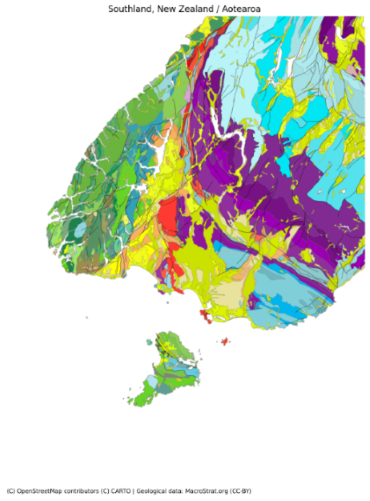

- Map created with [contextily](https://contextily.readthedocs.io/) Python package using the Place API
- Uses the [Macrostrat](https://macrostrat.org/) tile layer

  > Macrostrat is a platform for the aggregation and distribution of geological data relevant to the spatial and temporal distribution of sedimentary, igneous, and metamorphic rocks as well as data extracted from them.
- The colours are related to the lithology ie the physical characteristics of a rock, including colour, composition, and texture

## Southland, New Zealand Walking Trails

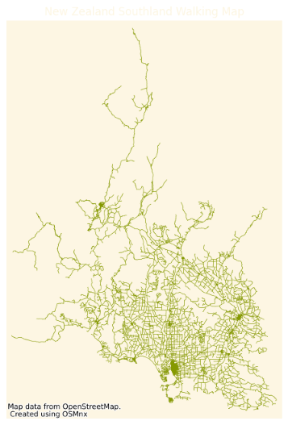

- Map created with [OSMnx](https://osmnx.readthedocs.io/) Python package

  > OSMnx is a Python package to easily download, model, analyze, and visualize street networks and other geospatial features from OpenStreetMap.
- OSMnx is built on Matplotlib and you can customise OSMnx plots using Matplotlib's API

# Utrecht, Netherlands

## Utrecht Drive Map

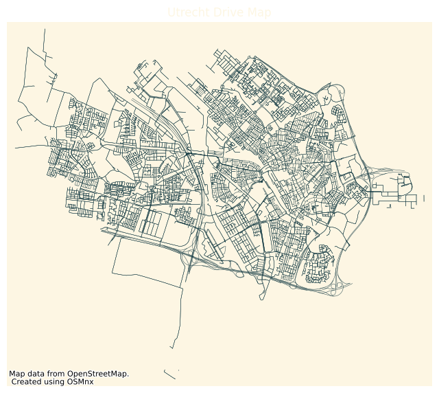

## Utrecht Bike Map

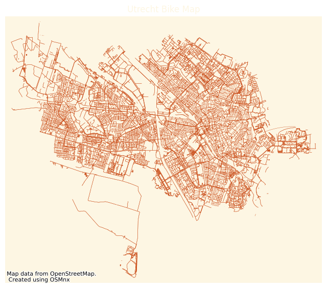

# Indonesia

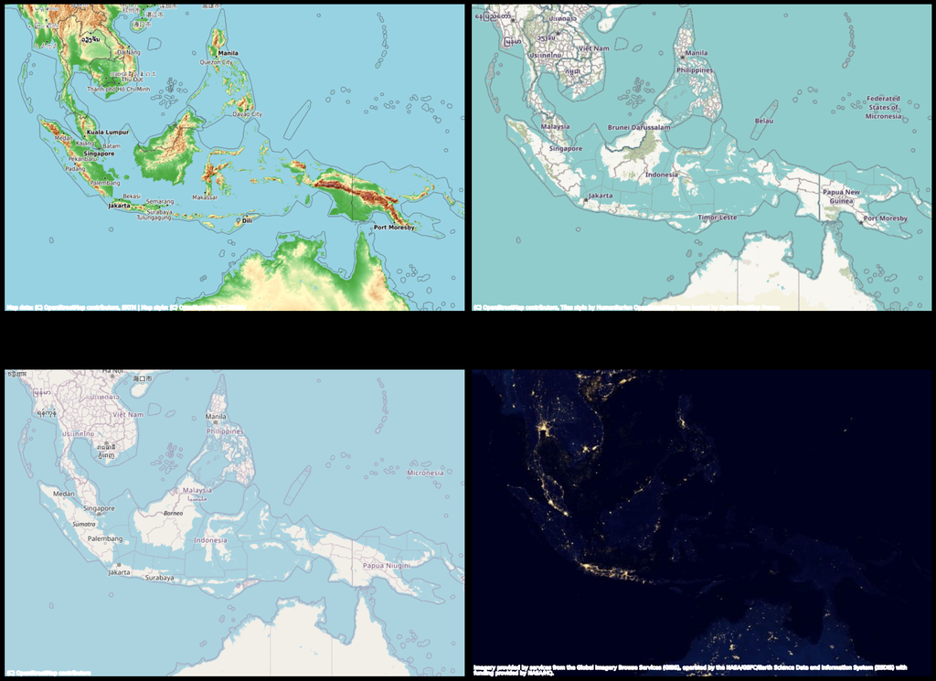

## Volcanoes in Indonesia

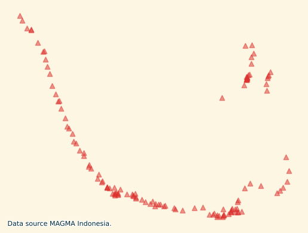

- Map created and customised with [Matplotlib](https://matplotlib.org/) Python package

# Conclusion

**The tools that made this presentation possible:**

- [Jupyter notebooks](https://jupyter.org/) for interactively developing Python
- [OSMnx](https://osmnx.readthedocs.io/) is pronounced as the initialism: “oh-ess-em-en-ex”. It is built on top of NetworkX and GeoPandas, and interacts with OpenStreetMap APIs
- [contextily](https://contextily.readthedocs.io/en/latest/) package to retrieve tile maps from the internet
- [nbconvert](https://nbconvert.readthedocs.io/) package to convert Notebooks to other formats
- [reveal.js & theme solarized](https://github.com/hakimel/reveal.js/blob/master/css/theme/source/solarized.scss) to create slides with one palette
- [Netlify](https://www.netlify.com/) to deploy the presentation.slides.html to a custom URL

**What I learnt**

- How to static maps that look like wall art
- Matplotlib is a useful and compatible base mapping package
- Rapid prototyping and plotting with matplotlib seemed straightforward
- Customisation seems finicky with a steeper learning curve with matplotlib https://stackoverflow.com/questions/40796117/how-do-i-make-the-width-of-the-title-box-span-the-entire-plot
- Agentic AI was great at scaffolding the initial project and telling me "You're right". In this project I preferred googling blogs and reading docs to learn these new Python packages

# References

- Boeing, G. (2025). Modeling and Analyzing Urban Networks and Amenities with OSMnx. Geographical Analysis, published online ahead of print. doi:10.1111/gean.70009
- [Interactive presentations from a Jupyter Notebook](https://emasuriano.com/til/2024-07-01-create-presentations-from-notebook/)
- [x lines of Python: static basemaps with contextily](https://agilescientific.com/blog/x-lines-of-python-static-basemaps)

# Thank you

Slides available at https://artofmaps2.netlify.app

The code available at https://github.com/kimnewzealand/art-of-maps-2